# Buzzfeed Tasty’s Facebok Posts in the Last 7 Days

## Overview

This project is an exploration project of Buzzfeed Tasty’s Facebook posts, the posts’ audience reach and attempts to evaluate the impact of the posts with the highest audience reach.

The first part of this project aims to scrape data directly from saved html document of the Buzzfeed Tasty Facebook page with the R package ‘rvest’. A Google Chrome add-on ‘Social Fixer’ has been used to save Tasty’s Facebook posts from 2018 July 27th, 3:00PM to 2018 July 20th, 3:00PM, at a total of 164 posts. Each post is treated as an observation, with key variables to extract, including:

Post title Post date Number of likes (includes all reactions) Number of comments Number of shares

The second part of this project will take the data scraped and explore the underlying audience reach, trends and interesting insights.

## Part I: Data Scraping

The project has been setup with basic packages such as ‘ggplot2’ and ‘dplyr’. The key package used for this web scraping process is ‘rvest’.

First, the exported html file is read, and each individual post is saved into the list i_post. This is done by selecting the nodes where the class includes all components of the post (excluding the comment section).

Taking a look at the length of the post list, we see that the length is 197, which does not match our expected 164 post number.

```r
webpage <- read_html("Tasty - Home.htm")

i_post <-
  webpage %>%
  html_nodes(xpath = "//div[@class='_4-u2 _4-u8']")
length(i_post)
```

```
## [1] 197
```

Taking a look at the first 5 entries of i_post in text form, we see that some header sections or pinned posts are also included in our list.

```r
html_text(i_post[1:5])
```

```
## [1] "Pages Liked by This PageLikeTasty DemaisLikeBuzzFeed HealthLikedProper Tasty"
## [2] "VideosTop Ten Tasty Recipes Of All Time222K33KFried Cinnamon Crunch Cheesecake Bites19K5.2KLasagna Dome184K46KSee All"
## [3] "PhotosSee All"
## [4] "Tasty · 1 hr · You feta believe these are delicious.tasty.coSpinach And Feta Baked Egg Cups Recipe by TastyHere's what you need: large egg, baby spinach, crumbled feta cheese, diced tomato, salt, ground black pepper40 Comments120 Shares428164449449LikeShow more reactionsCommentShareMost Rele…
## [5] "Tasty · 2 hrs · \"Coooookies! Nom nom nom nom!\" —a great manbuzzfeed.comHow Normal Are Your Cookie Opinions?\"Coooookies! Nom nom nom nom!\" —a great man9 Comments29 Shares577295616616LikeShow more reactionsCommentShareMost RelevantCommentsWrite a comment...Shelby Ivey  Excuuuuuuse ya’ll, M…
```

We will manually exclude the first 3 entries in our i_post list since they are either header components or pinned posts, but as we examine the length of our i_post list, we’ll realize it is still far from our expected list length of 164.

```r
i_post[1:3] <- NULL
length(i_post)
```

```
## [1] 194
```

With some looking around near the expected tail of the i_post list, it can be confirmed that the 164th post contains the desired “last post”, posted on July 20th at 3:00PM. The posts after the 164th will be trimmed from the list.

```r
html_text(i_post[164])
```

```
## [1] "Tasty · July 20 at 3:00 PM · You seriously need to stop throwing pasta against a wall.buzzfeed.com12 Myths About Cooking Pasta That Actually Aren't TrueYou seriously need to stop throwing pasta against a wall.622 Comments328 Shares2.8K134683K3KLikeShow more reactionsCommentShareMost Relevant…
```

```r
i_post[165:194] <- NULL
length(i_post)
```

```
## [1] 164
```

Now that we have a list with each individual post between the 7-day period stored in each element, we will pre-define vectors to store our variable values.

```r
#Define attributes of interest with default values and length of 164
post_title <- rep("na",164)
post_date <- rep("na",164)

numlike <- rep(0,164)
numcomment <- rep(0,164)
numshare <- rep(0,164)

is_video <- logical(164)
is_sharepost <- logical(164)
```

Functions had been written for extracting each variable from the list of posts. The functions are sourced into our current file.

```r
source("extract_info.R")
```

As the extraction function outputs our variables in the desired format other than the date, which is outputted as characters instead of dates, we format the post_date vector into date and time before we combine all the variables into a single data frame.

```r
#Assign each extracted values into vectors
for(i in 1:164){
  post_title[i] <- extract.post(i)
  post_date[i] <- extract.date(i)
  numlike[i] <- extract.likes(i)
  numcomment[i] <- extract.comments(i)
  numshare[i] <- extract.shares(i)
  is_video[i] <- is.video(i)
}

#format character dates into datetime dates
post_date_formatted <- as.POSIXct(post_date,tz = "Asia/Shanghai", "%m/%d/%Y %I:%M%p")

#combine vectors into data frame
tasty_fb <- data_frame(title = post_title, date = post_date_formatted, numlikes = numlike, numcomments = numcomment, numshares = numshare, isvideo = is_video)

str(tasty_fb)
```

```
## Classes 'tbl_df', 'tbl' and 'data.frame':    164 obs. of  6 variables:
##  $ title      : chr  "Spinach And Feta Baked Egg Cups Recipe by Tasty" "How Normal Are Your Cookie Opinions?" "Blueberry Lemon Yogurt Muffins Recipe by Tasty" "How Many Of These Expired Foods Are You Eating?" ...
##  $ date       : POSIXct, format: "2018-07-27 15:00:00" "2018-07-27 14:00:00" ...
##  $ numlikes   : num  448 611 1060 414 679 ...
##  $ numcomments: num  40 9 88 246 56 47 439 40 1500 9100 ...
##  $ numshares  : num  120 29 371 74 41 420 2700 42 4300 4900 ...
##  $ isvideo    : logi  FALSE FALSE FALSE FALSE FALSE FALSE ...
```

Now that we have a nice data frame going from the Buzzfeed Tasty posts from July 20th 2018 to July 27th 2018, it’s time to take a look at what insights these data offer.

## Part II: Data Analysis

### Audience Reaction Variables

#### Overview

First, we will evaluate our audience reaction variables, numlikes, numcomments, and numshare. It is quite intuitive to think that the more likes a post has, the more comments it’ll recieve (positive correlation), but a quick graph of numcomments to numlikes (left) does not show this very clearly, with most of the points clogged around the origin.

A log scale is applied (right), and now a clearer positive correlation is visible between the two variables.

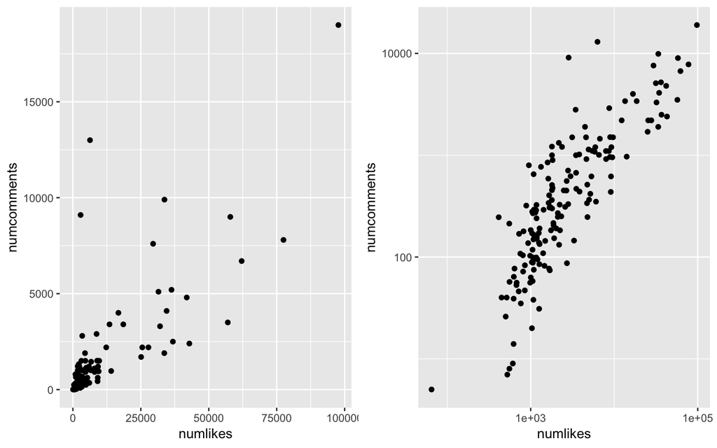

By identifying which of the posts are video posts, we can see that most video posts recieve more than 10K likes, and 1000 comments. These fit our expectations as Buzzfeed Tasty is best known for their cooking videos! For the simplicity of this analysis, shared videos (non-original content) will not be considered as videos.

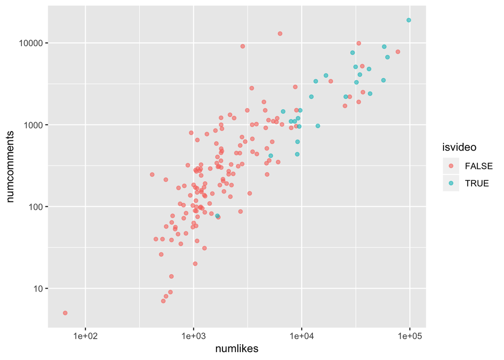

Applying this format to share~like and comment~share, it can be observed that the linear relationship and distribution is similar across the 3 reaction variables.

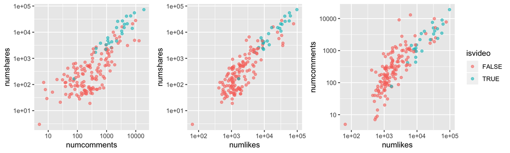

#### Reaction outliers

There is though one interesting outlier with less than 3000 likes, 100 comments and 300 shares. After a look at the title, it is clear that this is an original video made by Buzzfeed Tasty, but only to promote their Cookbook. This explains the lower number of reactions.

```
## # A tibble: 1 x 1
##   title
##   <chr>
## 1 " Get the Tasty Latest & Greatest Cookbook (AKA the PERFECT gift) NOW! G…
```

```
## # A tibble: 1 x 4
##   numlikes numcomments numshares isvideo
##      <dbl>       <dbl>     <dbl> <lgl>
## 1     1660          77       166 TRUE
```

On the topic of outliers, let’s also take this chance to examine our outlier minimum, a data point with less than 10 comments and 100 likes. Unlike the advertisement video shown previously, this post title doesn’t seem very out of the ordinary.

```
## # A tibble: 1 x 1
##   title
##   <chr>
## 1 20 Hysterical Tweets About Cooking That Will Make You Laugh Out Loud
```

```
## # A tibble: 1 x 5
##   date                numlikes numcomments numshares isvideo
##   <dttm>                 <dbl>       <dbl>     <dbl> <lgl>
## 1 2018-07-22 17:00:00       65           5         3 FALSE
```

By examining the neighboring post titles, it seems like this post was accidentally posted 2 times in a row, which explains the low number of reactions. The duplicate post seems to have recieved relatively normal amounts of reactions from the audience, although still on the lower end of the spectrum.

```
## # A tibble: 7 x 1
##   title
##   <chr>
## 1 The Hardest Game Of “Which Dessert Must Go” You’ll Ever Play
## 2 Chicken Pesto And Zucchini “Pasta” Recipe by Tasty
## 3 20 Hysterical Tweets About Cooking That Will Make You Laugh Out Loud
## 4 20 Hysterical Tweets About Cooking That Will Make You Laugh Out Loud
## 5 Liquid Nitrogen Ice Cream 4 Ways | Recipes
## 6 "Can You Make It Through This Fast Food \"Would You Rather\"?"
## 7 Red Wine Pasta Recipe by Tasty
```

```
## # A tibble: 2 x 1
##   title
##   <chr>
## 1 20 Hysterical Tweets About Cooking That Will Make You Laugh Out Loud
## 2 20 Hysterical Tweets About Cooking That Will Make You Laugh Out Loud
```

```
## # A tibble: 2 x 5
##   date                numlikes numcomments numshares isvideo
##   <dttm>                 <dbl>       <dbl>     <dbl> <lgl>
## 1 2018-07-22 17:00:00     1462          82        65 FALSE
## 2 2018-07-22 17:00:00       65           5         3 FALSE
```

#### The “Reach” index

Now that we’ve started to explore the reaction variables to posts, it is time to include the “reach” factor into our analysis. This project defines audience reach based on user reactions such as likes, comments and shares, based on the assumption that Facebook shows the original post when friends of a user react to posts. The more reaction a post gets, the broader the reach of the post.

As we lack knowledge to how each reaction affects the display of the post on a friend’s Newsfeed, we will omit weighting the reaction variables and stick with a simple model of summing up all the reactions for a “reach” index.

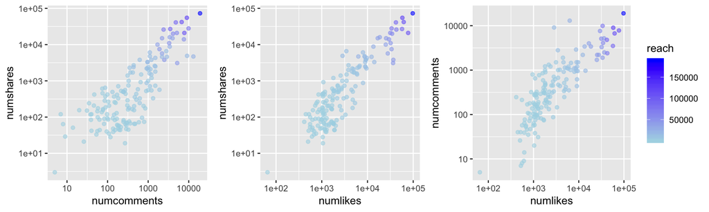

#### Post date and post frequency

When first observing the structure of the tasty_fb data frame, one interesting thing that stood out was how precisely timed the posts were. This is understandable as these posts and videos are most likely made in advance and posted with a program when they’re “mass produced” in Buzzfeed. To better understand the posting trends, the time has been converted to LA timezone (PDT).

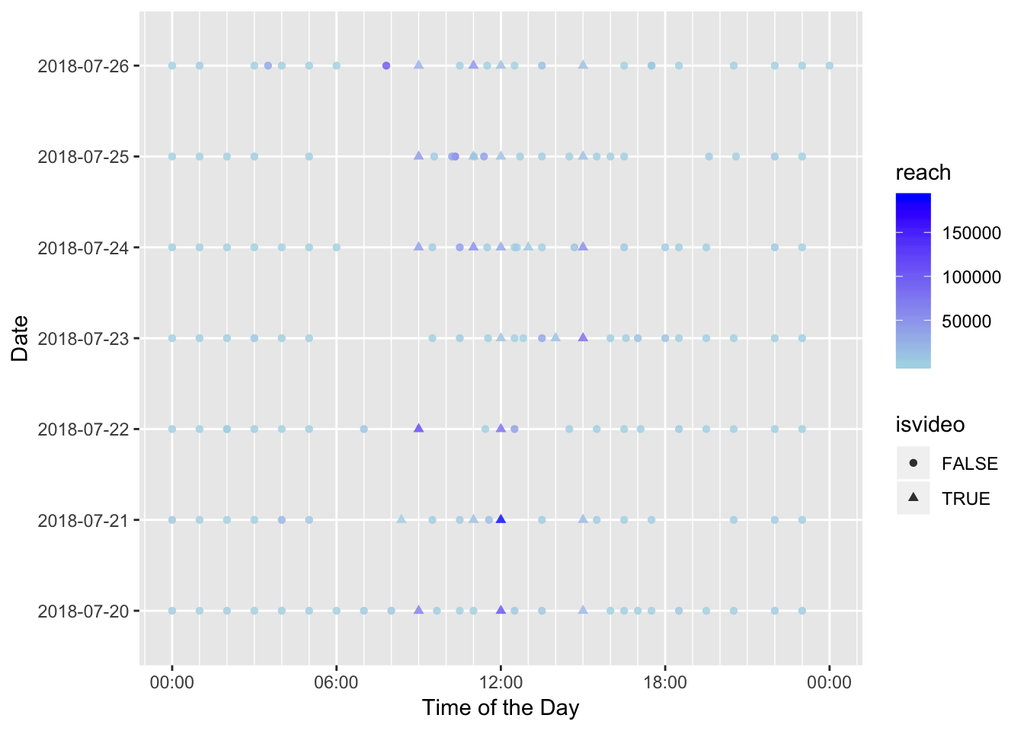

### Maximum reach and trend impact

Now that we’ve explored the reaction variables and defined our reach index, we’ll be using the reach index to identify our high and low reach posts, and examine their impact on Google Trends.

```
## # A tibble: 6 x 4
##   title                                       isvideo  reach time_us
##   <chr>                                       <lgl>    <dbl> <chr>
## 1 " You can't wait to get a bite of these cr… TRUE    189700 2018-07-21 1…
## 2 " Here's 5 ways you can meal prep the heal… TRUE    121925 2018-07-22 0…
## 3 " This chicken teriyaki fried rice dome is… TRUE    110800 2018-07-20 1…
## 4 Watching cookies being decorates is SO soo… FALSE   106300 2018-07-26 0…
## 5 " Shake up your morning with these flavor-… TRUE     87699 2018-07-23 1…
## 6 " These chocolate cheesecake pudding cups … TRUE     87500 2018-07-22 1…
```

From the sorted posts, we select the head (top 6) posts for our trend evaluation. Taking a look at the title of the post, the following keywords were selected as potential search terms based on the topic/title of the posts:

- jalapeño poppers
- meal prep
- chicken teriyaki fried rice
- decorated cookies (Holly Fox’s instagram)
- breakfast bomb
- chocolate cheesecake pudding

With the gtrendsR package, we will be extracting Google trends data on these search terms. As the earliest post was posted on 2018-07-20 and latest post posted on 2018-07-26, we will set our evaluation dates to range from 2018-07-17 (3 days prior to earliest post) to 2018-07-29 (3 days after latest post). We will be looking specifically at the interest over time worldwide from Google Trends.

```r
#Set system environment timezone to US/LA so that gtrends data returned are based on LA time
Sys.setenv(TZ = "America/Los_angeles")

#call gtrends package for interest over time according to selected topics
gtrend_jalapeno <- gtrends("jalapeno poppers",time= "2018-07-17 2018-07-29")$interest_over_time
gtrend_mealprep <- gtrends("meal prep", time= "2018-07-17 2018-07-29")$interest_over_time
gtrend_friedrice <- gtrends("chicken teriyaki fried rice", time= "2018-07-17 2018-07-29")$interest_over_time
gtrend_cookies <- gtrends("Holly Fox", time= "2018-07-17 2018-07-29")$interest_over_time
gtrend_breakfast <- gtrends("breakfast bomb", time= "2018-07-17 2018-07-29")$interest_over_time
gtrend_chocopudding <- gtrends("chocolate cheesecake pudding", time= "2018-07-17 2018-07-29")$interest_over_time

#create master frame for faceting
gtrend_master <- bind_rows(gtrend_jalapeno,gtrend_mealprep,gtrend_friedrice,gtrend_cookies,gtrend_breakfast,gtrend_chocopudding)
gtrend_master$date <- as.POSIXct(as.character(gtrend_master$date), tz="America/Los_angeles")

#create factor keyword for faceting order
gtrend_master$keyword_f <- factor(gtrend_master$keyword, levels = c("jalapeno poppers", "meal prep", "chicken teriyaki fried rice", "Holly Fox","breakfast bomb", "chocolate cheesecake pudding"))

#organize top 6 (head) posts from sorted posts to graph, selecting the post time and associated keywords
tasty_fb_top6 <- head(tasty_fb_sorted) %>%
  select(time_us) %>%
  mutate(keyword_f = unique(gtrend_master$keyword_f))
```

As the top posts are mainly videos, we will also add in trends on Youtube for referencing. The retrieving process has been completed behind the scene, so we’ll be joining the youtube hits with the original dataset of web hits.

```r
gtrend_master <- yt_master %>%
  select(date,keyword,youtube_hits) %>%
  right_join(gtrend_master, by = c("keyword","date"))
```

With our Google Trends data ready, let’s take a look at whether web search trends (black) and Youtube trends (red) are actually affected by our most popular Buzzfeed Tasty posts. The post date is labeled with the blue vertical line:

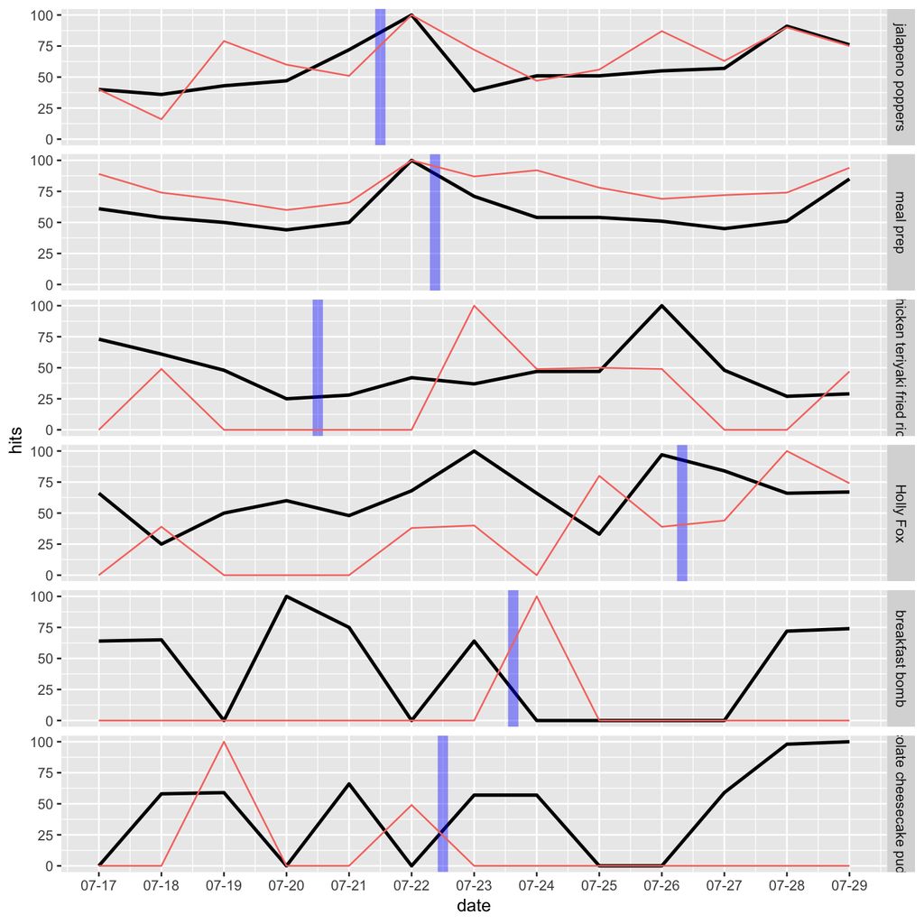